# Coursework 2 for Cardiac MR Image Segmentation (2020-2021)

## Introduction

CMRI allows for a non-invasive examination of the heart. Applying image segmentation allows for calculation of important quantitative measures such as right and left ventricle volume, myocardial mass, and ejection fraction (Chen, Chen et al., 2020). These measures then allow for diagnosis of (possibly fatal) heart conditions.

This is the ideal problem for a convolutional neural network - indeed as technology and deep learning have developed, the area of medical imagery has benefited greatly. Applying a CNN to pixel-wise classification allows for a much faster and less error-prone method of segmentation.

The dice score ranges between 0 and 1 with 0 being completely wrong and 1 being a perfect match. Since there are 4 classes to be segmented then even if the theoretical minimum is 0, by just classifying each pixel at random will achieve a dice score of 0.25 (that is if each class occurs with equal frequency).

Below we define some two plotting functions: one that plots the image with the ground truth mask and another that plots the image with the ground truth mask and the predicted mask.

```python
from matplotlib import pyplot as plt
def show_image_mask(img, mask, cmap='gray'): # visualisation
    fig = plt.figure(figsize=(5,5))
    plt.subplot(1, 2, 1)
    plt.imshow(img, cmap=cmap)
    plt.axis('off')
    plt.subplot(1, 2, 2)
    plt.imshow(mask, cmap=cmap)
    plt.axis('off')

#Additional function that plots the predicted segmentation along with the image and the ground truth
def show_image_mask_pred(img, mask, pred, cmap='gray'):
    fig = plt.figure(figsize=(5,5))
    plt.subplot(1, 3, 1)
    plt.imshow(img, cmap=cmap) #CMRI
    plt.axis('off')
    plt.subplot(1, 3, 2)
    plt.imshow(mask, cmap=cmap) #ground truth mask
    plt.axis('off')
    plt.subplot(1, 3, 3)
    plt.imshow(pred, cmap=cmap) # predicted mask
    plt.axis('off')
    plt.show()
```

Next, we define two classes of data loaders to store the training, validating, and test data in memory. Note that the validation data loader will be an instance of the `TrainDataset` class.

```python
import torch
import torch.utils.data as data
import cv2
import os
from glob import glob
import numpy as np

class TrainDataset(data.Dataset):
    def __init__(self, root=''):
        super(TrainDataset, self).__init__()
        self.img_files = glob(os.path.join(root,'image','*.png'))
        self.mask_files = []
        for img_path in self.img_files:
            basename = os.path.basename(img_path)
            self.mask_files.append(os.path.join(root,'mask',basename[:-4]+'_mask.png'))

    def __getitem__(self, index):
            img_path = self.img_files[index]
            mask_path = self.mask_files[index]
            data = cv2.imread(img_path, cv2.IMREAD_UNCHANGED)
            label = cv2.imread(mask_path, cv2.IMREAD_UNCHANGED)
            return torch.from_numpy(data).float(), torch.from_numpy(label).float()

    def __len__(self):
        return len(self.img_files)

class TestDataset(data.Dataset):
    def __init__(self, root=''):
        super(TestDataset, self).__init__()
        self.img_files = glob(os.path.join(root,'image','*.png'))

    def __getitem__(self, index):
            img_path = self.img_files[index]
            data = cv2.imread(img_path, cv2.IMREAD_UNCHANGED)
            return torch.from_numpy(data).float()

    def __len__(self):
        return len(self.img_files)
```

## Implementation

Now we define the network architecture. We opted to use the SegNet architecture (Badrinarayanan, Kendall and Cipolla, 2015) which is an encoder-decoder model for image segmentation. The idea is that the model applies a sequence of increasingly large number of convolutional filters and max-pooling layers to map the image to a low dimensional space (but with a large number of channels) and then to reverse the process by up-sampling and convolutional layers to return the image back to the same dimensionality of the input. Below is the architecture of SegNet taken from their paper.

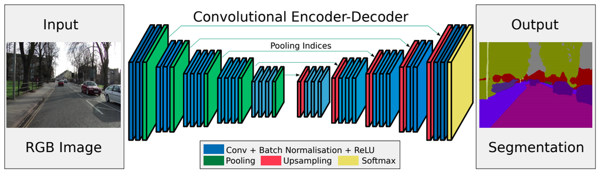

The first half of the network is the encoder and is topologically identical to the first 13 convolutional layers of the VGG16 architecture. Indeed, in the paper the authors apply transfer learning and initialise the encoder weights with the VGG16 weights. Then after the encoder there are 13 decoder layers each one corresponding to an encoder layer. At the end, instead of having a fully connected layer (such as the one found in VGG16), SegNet opts to map straight from the high-resolution feature map straight to a pixel-wise softmax classification. Each convolutional layer uses a 3x3 kernel with 1 padding. The number of filters can be seen in the code below. The other notable feature of SegNet is the connection between each max-pooling layer and its corresponding up-sampling. When the down-pooling occurs, the model stores the index of where the maximum value in the max-pooling occurs and uses those indices to up-sample. Below we define the model in `CNNSEG()`.

```python
import torch
import torch.nn as nn
import torch.nn.functional as F

class CNNSEG(nn.Module):
    def __init__(self):
        super(CNNSEG, self).__init__()
        #Encoder layers
        self.encoder_00 = nn.Sequential(*[nn.Conv2d(in_channels=1,out_channels=64,kernel_size=3,padding=1),
                                                nn.BatchNorm2d(64)])

        self.encoder_01 = nn.Sequential(*[nn.Conv2d(in_channels=64,out_channels=64,kernel_size=3,padding=1),
                                                nn.BatchNorm2d(64)])

        self.encoder_10 = nn.Sequential(*[nn.Conv2d(in_channels=64,out_channels=128,kernel_size=3,padding=1),
                                                nn.BatchNorm2d(128)])

        self.encoder_11 = nn.Sequential(*[nn.Conv2d(in_channels=128,out_channels=128,kernel_size=3,padding=1),
                                                nn.BatchNorm2d(128)])

        self.encoder_20 = nn.Sequential(*[nn.Conv2d(in_channels=128,out_channels=256,kernel_size=3,padding=1),
                                                nn.BatchNorm2d(256)])

        self.encoder_21 = nn.Sequential(*[nn.Conv2d(in_channels=256,out_channels=256,kernel_size=3,padding=1),
                                                nn.BatchNorm2d(256)])

        self.encoder_22 = nn.Sequential(*[nn.Conv2d(in_channels=256,out_channels=256,kernel_size=3,padding=1),
                                                nn.BatchNorm2d(256)])

        self.encoder_30 = nn.Sequential(*[nn.Conv2d(in_channels=256,out_channels=512,kernel_size=3,padding=1),
                                                nn.BatchNorm2d(512)])

        self.encoder_31 = nn.Sequential(*[nn.Conv2d(in_channels=512,out_channels=512,kernel_size=3,padding=1),
                                                nn.BatchNorm2d(512)])

        self.encoder_32 = nn.Sequential(*[nn.Conv2d(in_channels=512,out_channels=512,kernel_size=3,padding=1),
                                                nn.BatchNorm2d(512)])

        self.encoder_40 = nn.Sequential(*[nn.Conv2d(in_channels=512,out_channels=512,kernel_size=3,padding=1),
                                                nn.BatchNorm2d(512)])

        self.encoder_41 = nn.Sequential(*[nn.Conv2d(in_channels=512,out_channels=512,kernel_size=3,padding=1),
                                                nn.BatchNorm2d(512)])

        self.encoder_42 = nn.Sequential(*[nn.Conv2d(in_channels=512,out_channels=512,kernel_size=3,padding=1),
                                                nn.BatchNorm2d(512)])

        #Decoder layers


        self.decoder_42 = nn.Sequential(*[nn.ConvTranspose2d(in_channels=512,out_channels=512,
                                                             kernel_size=3,padding=1),
                                                nn.BatchNorm2d(512)])

        self.decoder_41 = nn.Sequential(*[nn.ConvTranspose2d(in_channels=512,out_channels=512,
                                                             kernel_size=3,padding=1),
                                                nn.BatchNorm2d(512)])

        self.decoder_40 = nn.Sequential(*[nn.ConvTranspose2d(in_channels=512,out_channels=512,
                                                             kernel_size=3,padding=1),
                                                nn.BatchNorm2d(512)])

        self.decoder_32 = nn.Sequential(*[nn.ConvTranspose2d(in_channels=512,out_channels=512,
                                                             kernel_size=3,padding=1),
                                                nn.BatchNorm2d(512)])

        self.decoder_31 = nn.Sequential(*[nn.ConvTranspose2d(in_channels=512,out_channels=512,
                                                             kernel_size=3,padding=1),
                                                nn.BatchNorm2d(512)])

        self.decoder_30 = nn.Sequential(*[nn.ConvTranspose2d(in_channels=512,out_channels=256,
                                                             kernel_size=3,padding=1),
                                                nn.BatchNorm2d(256)])

        self.decoder_22 = nn.Sequential(*[nn.ConvTranspose2d(in_channels=256,out_channels=256,
                                                             kernel_size=3,padding=1),
                                                nn.BatchNorm2d(256)])

        self.decoder_21 = nn.Sequential(*[nn.ConvTranspose2d(in_channels=256,out_channels=256,
                                                             kernel_size=3,padding=1),
                                                nn.BatchNorm2d(256)])

        self.decoder_20 = nn.Sequential(*[nn.ConvTranspose2d(in_channels=256,out_channels=128,
                                                             kernel_size=3,padding=1),
                                                nn.BatchNorm2d(128)])

        self.decoder_11 = nn.Sequential(*[nn.ConvTranspose2d(in_channels=128,out_channels=128,
                                                             kernel_size=3,padding=1),
                                                nn.BatchNorm2d(128)])

        self.decoder_10 = nn.Sequential(*[nn.ConvTranspose2d(in_channels=128,out_channels=64,
                                                             kernel_size=3,padding=1),
                                                nn.BatchNorm2d(64)])

        self.decoder_01 = nn.Sequential(*[nn.ConvTranspose2d(in_channels=64,out_channels=64,
                                                             kernel_size=3,padding=1),
                                                nn.BatchNorm2d(64)])

        self.decoder_00 = nn.Sequential(*[nn.ConvTranspose2d(in_channels=64,out_channels=4,
                                                             kernel_size=3,padding=1)])


    def forward(self, x):
        # Encoder

        # Encoder Stage - 1
        dim_0 = x.size()
        x_00 = F.relu(self.encoder_00(x))
        x_01 = F.relu(self.encoder_01(x_00))
        x_0, indices_0 = F.max_pool2d(x_01, kernel_size=2, stride=2, return_indices=True)

        # Encoder Stage - 2
        dim_1 = x_0.size()
        x_10 = F.relu(self.encoder_10(x_0))
        x_11 = F.relu(self.encoder_11(x_10))
        x_1, indices_1 = F.max_pool2d(x_11, kernel_size=2, stride=2, return_indices=True)

        # Encoder Stage - 3
        dim_2 = x_1.size()
        x_20 = F.relu(self.encoder_20(x_1))
        x_21 = F.relu(self.encoder_21(x_20))
        x_22 = F.relu(self.encoder_22(x_21))
        x_2, indices_2 = F.max_pool2d(x_22, kernel_size=2, stride=2, return_indices=True)

        # Encoder Stage - 4
        dim_3 = x_2.size()
        x_30 = F.relu(self.encoder_30(x_2))
        x_31 = F.relu(self.encoder_31(x_30))
        x_32 = F.relu(self.encoder_32(x_31))
        x_3, indices_3 = F.max_pool2d(x_32, kernel_size=2, stride=2, return_indices=True)

        # Encoder Stage - 5
        dim_4 = x_3.size()
        x_40 = F.relu(self.encoder_40(x_3))
        x_41 = F.relu(self.encoder_41(x_40))
        x_42 = F.relu(self.encoder_42(x_41))
        x_4, indices_4 = F.max_pool2d(x_42, kernel_size=2, stride=2, return_indices=True)

        # Decoder

        # Decoder Stage - 5
        x_4d = F.max_unpool2d(x_4, indices_4, kernel_size=2, stride=2, output_size=dim_4)
        x_42d = F.relu(self.decoder_42(x_4d))
        x_41d = F.relu(self.decoder_41(x_42d))
        x_40d = F.relu(self.decoder_40(x_41d))

        # Decoder Stage - 4
        x_3d = F.max_unpool2d(x_3, indices_3, kernel_size=2, stride=2, output_size=dim_3)
        x_32d = F.relu(self.decoder_32(x_3d))
        x_31d = F.relu(self.decoder_31(x_32d))
        x_30d = F.relu(self.decoder_30(x_31d))

        # Decoder Stage - 3
        x_2d = F.max_unpool2d(x_30d, indices_2, kernel_size=2, stride=2, output_size=dim_2)
        x_22d = F.relu(self.decoder_22(x_2d))
        x_21d = F.relu(self.decoder_21(x_22d))
        x_20d = F.relu(self.decoder_20(x_21d))

        # Decoder Stage - 2
        x_1d = F.max_unpool2d(x_20d, indices_1, kernel_size=2, stride=2, output_size=dim_1)
        x_11d = F.relu(self.decoder_11(x_1d))
        x_10d = F.relu(self.decoder_10(x_11d))

        # Decoder Stage - 1
        x_0d = F.max_unpool2d(x_10d, indices_0, kernel_size=2, stride=2, output_size=dim_0)
        x_01d = F.relu(self.decoder_01(x_0d))
        x_00d = self.decoder_00(x_01d)

        x_softmax = F.softmax(x_00d, dim=1)

        return x_softmax

model = CNNSEG()
model.cuda()
```

We can see the summary of the model including the shape of the tensor at each step and the number of trainable parameters. Due to the fact that the network is fully convolutional and the use of max-pooling indices in up-sampling allows the model to have relatively less trainable parameters.

```python
from torchsummary import summary
summary(model, (1, 96, 96))
```

```
----------------------------------------------------------------
        Layer (type)               Output Shape         Param #
================================================================
            Conv2d-1           [-1, 64, 96, 96]             640
       BatchNorm2d-2           [-1, 64, 96, 96]             128
            Conv2d-3           [-1, 64, 96, 96]          36,928
       BatchNorm2d-4           [-1, 64, 96, 96]             128
            Conv2d-5          [-1, 128, 48, 48]          73,856
       BatchNorm2d-6          [-1, 128, 48, 48]             256
            Conv2d-7          [-1, 128, 48, 48]         147,584
       BatchNorm2d-8          [-1, 128, 48, 48]             256
            Conv2d-9          [-1, 256, 24, 24]         295,168
      BatchNorm2d-10          [-1, 256, 24, 24]             512
           Conv2d-11          [-1, 256, 24, 24]         590,080
      BatchNorm2d-12          [-1, 256, 24, 24]             512
           Conv2d-13          [-1, 256, 24, 24]         590,080
      BatchNorm2d-14          [-1, 256, 24, 24]             512
           Conv2d-15          [-1, 512, 12, 12]       1,180,160
      BatchNorm2d-16          [-1, 512, 12, 12]           1,024
           Conv2d-17          [-1, 512, 12, 12]       2,359,808
      BatchNorm2d-18          [-1, 512, 12, 12]           1,024
           Conv2d-19          [-1, 512, 12, 12]       2,359,808
      BatchNorm2d-20          [-1, 512, 12, 12]           1,024
           Conv2d-21            [-1, 512, 6, 6]       2,359,808
      BatchNorm2d-22            [-1, 512, 6, 6]           1,024
           Conv2d-23            [-1, 512, 6, 6]       2,359,808
      BatchNorm2d-24            [-1, 512, 6, 6]           1,024
           Conv2d-25            [-1, 512, 6, 6]       2,359,808
      BatchNorm2d-26            [-1, 512, 6, 6]           1,024
  ConvTranspose2d-27            [-1, 512, 6, 6]       2,359,808
      BatchNorm2d-28            [-1, 512, 6, 6]           1,024
  ConvTranspose2d-29            [-1, 512, 6, 6]       2,359,808
      BatchNorm2d-30            [-1, 512, 6, 6]           1,024
  ConvTranspose2d-31            [-1, 512, 6, 6]       2,359,808
      BatchNorm2d-32            [-1, 512, 6, 6]           1,024
  ConvTranspose2d-33          [-1, 512, 12, 12]       2,359,808
      BatchNorm2d-34          [-1, 512, 12, 12]           1,024
  ConvTranspose2d-35          [-1, 512, 12, 12]       2,359,808
      BatchNorm2d-36          [-1, 512, 12, 12]           1,024
  ConvTranspose2d-37          [-1, 256, 12, 12]       1,179,904
```

[output cut: 9 more lines]

```
  ConvTranspose2d-47           [-1, 64, 48, 48]          73,792
      BatchNorm2d-48           [-1, 64, 48, 48]             128
  ConvTranspose2d-49           [-1, 64, 96, 96]          36,928
      BatchNorm2d-50           [-1, 64, 96, 96]             128
  ConvTranspose2d-51            [-1, 4, 96, 96]           2,308
================================================================
Total params: 29,444,164
Trainable params: 29,444,164
Non-trainable params: 0
----------------------------------------------------------------
Input size (MB): 0.04
Forward/backward pass size (MB): 63.28
Params size (MB): 112.32
Estimated Total Size (MB): 175.64
----------------------------------------------------------------
```

In accordance with the SegNet paper, the loss function was chosen to be categorical cross-entropy. This is the natural choice for classification problems and is perfect for our case as we are performing pixel-wise classification. Unlike in the paper, we opted to use the Adam optimiser as it is currently one of the most popular optimisers. We allow pytorch to use GPU acceleration if it is available. Lastly, we initialise the learning rate at 0.001 as well as training, validation loss and dice score lists to store the training history.

```python
#Set the learning rate
LEARNING_RATE = 0.001

#Initialise cross entropy loss and adam optimizer
loss_fn = torch.nn.CrossEntropyLoss()
optimizer = torch.optim.Adam(model.parameters(),
                                     lr=LEARNING_RATE)

#if gpu is available then it sends it to gpu else it uses cpu
device = torch.device("cuda" if torch.cuda.is_available() else "cpu")
model.to(device)
if torch.cuda.is_available():
    model.cuda()

#Initialise list to store loss over training
train_loss = list()
val_loss = list()
dice_score = list()
```

Below we define some helper functions:

- `categorical_dice` which computes the categorical dice between two masks for a specific class. Small correction has been made to the code provided.
- `forward` which preprocesses the image tensor by making it the right dimension and dividing each element component-wise by 255 to make the tensor lie inside the hypercube (granted of very high dimension). The gradients get set to zero in the optimiser and we push the mini-batch forwards through the network and return the softmax output of the model as a tensor of shape Bx4x96x96 where B is the batch size, 4 corresponds to the four categories and 96x96 is the image pixels.

```python
#categorical dice score between mask1 and mask2 along label_class
def categorical_dice(mask1, mask2, label_class=1):
    mask1_pos = (mask1 == label_class).numpy()
    mask2_pos = (mask2 == label_class).numpy()
    dice = 2 * np.sum(mask1_pos * mask2_pos) / (np.sum(mask1_pos) + np.sum(mask2_pos))
    return dice

#Packages proprocessing and forward pass
def forward(img):
    #scales image so that each pixel lies between 0 and 1
    img_scale = img/255.

    #reshapes the tensor
    img_scale = img_scale.unsqueeze(1)

    #resets optimiser
    optimizer.zero_grad()

    #pushes processed image through network
    seg_soft = model(img_scale)

    return seg_soft
```

We used Google Colab to perform the computations as this allowed for GPU acceleration. In order to access the data, we had to mount our Google drive.

```python
from google.colab import drive
drive.mount('/content/drive')
```

Using the `TrainDataset` class defined above as well as pytorch's `DataLoader` functionality, we create two data loaders. One for the training set and one for the validation set. Initial value of 10 for batch_size was chosen but later will be changed for experimentation.

```python
from torch.utils.data import DataLoader
#create path to data
data_path = '/content/drive/MyDrive/NC2020/NC_cw2/data/train'
val_path = '/content/drive/MyDrive/NC2020/NC_cw2/data/val'
#initialise number of workers and batch size for data loaders
num_workers = 8
batch_size = 10

#load data into data loaders and put the into a dict type
train_set = TrainDataset(data_path)
val_set = TrainDataset(val_path)

training_data_loader = DataLoader(dataset=train_set, num_workers=num_workers, batch_size=batch_size, shuffle=True)
validating_data_loader = DataLoader(dataset=val_set, num_workers=num_workers, batch_size=80, shuffle=True)


data_loader = {'train':training_data_loader,
              'validate':validating_data_loader}
```

Training is done in the standard way: we unpack the data from the data loader, it is then sent to the GPU (if it is available), pushed through the `forward()` function defined above that deals with preprocessing and doing the forward pass. The function returns the softmax activation of the model which is used to then compute the loss. The loss is passed backwards through the network and the optimiser takes a step. For each training step, the batch loss is computed and stored to keep track of training.

For the validation set, the model is set to not train. In a similar fashion, the image is passed through but once it reaches the loss stage, the loss is computed and stored without pushing it back through the network and optimising. The validation set is only used to prevent the model from over-fitting on the training data.

```python
def train(data_loader, optimizer, loss_fn, EPOCHS = 100, save_weights=False):
    """
    print('Loss function ', loss_fn )
    print('optimizer ', optimizer)
    print('Mini Batch size set to ', batch_size)
    print(device)
    """
    best_dice = 0
    train_loss = list()
    val_loss = list()
    dice_score = list()

    for epochs in range(EPOCHS):
        """
        print('-' * 10)
        print('Epoch {}/{}'.format(epochs+1, EPOCHS))
        """
        #TRAINING
        model.train(True)

        batch_loss = 0.0

        for index_train, sample in enumerate(data_loader['train']):

            #unpack data and send it to device (GPU/CPU)
            img, mask = sample
            img, mask = img.to(device), mask.to(device)

            #preprocess and pass through network
            soft_mask = forward(img)

            #compute and push back loss
            loss = loss_fn(soft_mask, mask.long())
            loss.backward()

            #optimise on the loss
            optimizer.step()

            batch_loss += loss.item()

        train_loss.append(batch_loss / (index_train + 1))

        #print("Train loss: ", train_loss[-1])

        #VALIDATING
        model.train(False)

        batch_loss = 0.0

        for index_val, sample in enumerate(data_loader['validate']):
            #unpack data and send to device
            img, mask = sample
            img, mask = img.to(device), mask.to(device)

            #preprocess and pass through network
            soft_mask = forward(img)

            #compute loss
            loss = loss_fn(soft_mask, mask.long())

            batch_loss += loss.item()

        val_loss.append(batch_loss / (index_val + 1))

        #compute and store categorical dice score
        dice_score_batch = np.mean([categorical_dice(mask.cpu(), torch.argmax(soft_mask, dim=1).cpu(), label_class=c)
                                    for c in [0,1,2,3]])

        dice_score.append(dice_score_batch)

        #check if this weight results in lowest validation loss

        if dice_score[-1] > best_dice and save_weights:
            torch.save(model.state_dict(), '/content/drive/MyDrive/NC2020/NC_cw2/segnet.pth')
            best_dice = dice_score[-1]
        """
        print("Validation loss: ", val_loss[-1])
        print("Dice score: ", dice_score_batch)
        """
    return train_loss, val_loss, dice_score
```

Calling the train function trains the model and returns the lists outlined above.

```python
train_loss, val_loss, dice_score = train(data_loader, optimizer, loss_fn)
```

```python
argmin = np.argmin(val_loss)
print("Validation loss: ", np.min(val_loss))
print("Dice score: ", dice_score[argmin])
```

```
Validation loss:  0.775014340877533
Dice score:  0.9025510646562028
```

The plots of loss and dice score throughout training are:

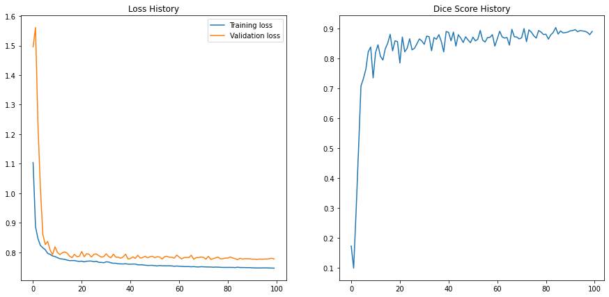

```python
fig = plt.figure(figsize=(15,7))
plt.subplot(1, 2, 1)
plt.plot(train_loss, label="Training loss")
plt.plot(val_loss, label="Validation loss")
plt.legend()
plt.title("Loss History")
plt.subplot(1, 2, 2)
plt.plot(dice_score)
plt.title("Dice Score History")
plt.show()
```

Looking at the graphs, the model trained in approximately 20 epochs. From then only small gains were achieved in the validation loss as the training loss kept decreasing progressively. This decrease of training loss is indicative of overfitting and represents the model learning the data instead of generalising. We made the choice to choose the weights with the highest dice score as opposed to the lowest validation loss. This will not affect the overall performance as these two metrics are highly negatively correlated.

## Experimentation

In order to optimise the model even further, we look to optimise the hyper-parameters. We will focus on tuning learning rate, batch size, and loss function.

The test values for the learning rate are as below and are chosen to give a wide range of possible values. Through experimentation, a learning rate above 0.005 did not converge.

We chose to look at three of the most popular loss functions for segmentation: cross entropy, focal loss, and boundary loss. The last two are defined in the next cell.

The training is performed over 20 epochs and the best validation loss and corresponding dice score are stored in their respective arrays.

```python
import torch
import torch.nn as nn
import torch.nn.functional as F
import numpy as np
from torch.autograd import Variable

class FocalLoss(nn.Module):
    def __init__(self, gamma=0, alpha=None, size_average=True):
        super(FocalLoss, self).__init__()
        self.gamma = gamma
        self.alpha = alpha
        if isinstance(alpha,(float,int)): self.alpha = torch.Tensor([alpha,1-alpha])
        if isinstance(alpha,list): self.alpha = torch.Tensor(alpha)
        self.size_average = size_average

    def forward(self, input, target):
        if input.dim()>2:
            input = input.view(input.size(0),input.size(1),-1)  # N,C,H,W => N,C,H*W
            input = input.transpose(1,2)    # N,C,H*W => N,H*W,C
            input = input.contiguous().view(-1,input.size(2))   # N,H*W,C => N*H*W,C
        target = target.view(-1,1)

        logpt = F.log_softmax(input)
        logpt = logpt.gather(1,target)
        logpt = logpt.view(-1)
        pt = Variable(logpt.data.exp())

        if self.alpha is not None:
            if self.alpha.type()!=input.data.type():
                self.alpha = self.alpha.type_as(input.data)
            at = self.alpha.gather(0,target.data.view(-1))
            logpt = logpt * Variable(at)

        loss = -1 * (1-pt)**self.gamma * logpt
        if self.size_average: return loss.mean()
        else: return loss.sum()

def one_hot(label, n_classes, requires_grad=True):
    """Return One Hot Label"""
    divce = label.device
    one_hot_label = torch.eye(
        n_classes, device=device, requires_grad=requires_grad)[label]
    one_hot_label = one_hot_label.transpose(1, 3).transpose(2, 3)

    return one_hot_label


class BoundaryLoss(nn.Module):
    """Boundary Loss proposed in:
    Alexey Bokhovkin et al., Boundary Loss for Remote Sensing Imagery Semantic Segmentation
    https://arxiv.org/abs/1905.07852
    """

    def __init__(self, theta0=3, theta=5):
        super().__init__()

        self.theta0 = theta0
        self.theta = theta

    def forward(self, pred, gt):
        """
        Input:
            - pred: the output from model (before softmax)
                    shape (N, C, H, W)
            - gt: ground truth map
                    shape (N, H, w)
        Return:
            - boundary loss, averaged over mini-bathc
        """

        n, c, _, _ = pred.shape

        # softmax so that predicted map can be distributed in [0, 1]
        pred = torch.softmax(pred, dim=1)

        # one-hot vector of ground truth
        one_hot_gt = one_hot(gt, c)

        # boundary map
        gt_b = F.max_pool2d(
            1 - one_hot_gt, kernel_size=self.theta0, stride=1, padding=(self.theta0 - 1) // 2)
        gt_b -= 1 - one_hot_gt

        pred_b = F.max_pool2d(
            1 - pred, kernel_size=self.theta0, stride=1, padding=(self.theta0 - 1) // 2)
        pred_b -= 1 - pred

        # extended boundary map
        gt_b_ext = F.max_pool2d(
            gt_b, kernel_size=self.theta, stride=1, padding=(self.theta - 1) // 2)

        pred_b_ext = F.max_pool2d(
            pred_b, kernel_size=self.theta, stride=1, padding=(self.theta - 1) // 2)

        # reshape
        gt_b = gt_b.view(n, c, -1)
        pred_b = pred_b.view(n, c, -1)
        gt_b_ext = gt_b_ext.view(n, c, -1)
        pred_b_ext = pred_b_ext.view(n, c, -1)

        # Precision, Recall
        P = torch.sum(pred_b * gt_b_ext, dim=2) / (torch.sum(pred_b, dim=2) + 1e-7)
        R = torch.sum(pred_b_ext * gt_b, dim=2) / (torch.sum(gt_b, dim=2) + 1e-7)

        # Boundary F1 Score
        BF1 = 2 * P * R / (P + R + 1e-7)

        # summing BF1 Score for each class and average over mini-batch
        loss = torch.mean(1 - BF1)

        return loss
```

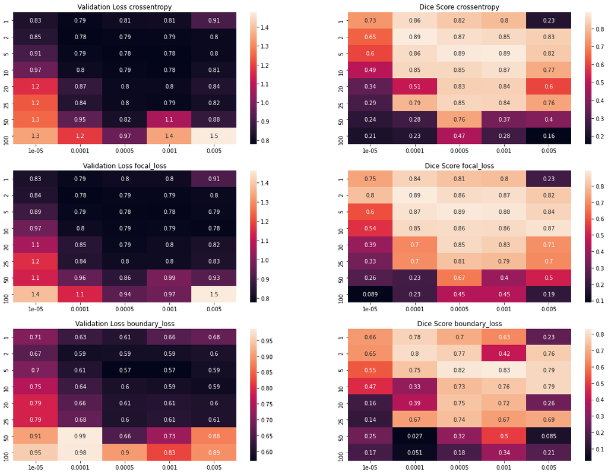

```python
import seaborn as sns
#hyper-parameter space lattice
batch_test_values = [1,2,5,10,20,25,50,100]
learning_rate_test_values = [1e-5, 1e-4, 5e-4, 1e-3, 5e-3]

fig, axs = plt.subplots(3, 2, figsize=(20,15))

#initialise results arrays
loss_array = np.zeros((len(batch_test_values), len(learning_rate_test_values)))
dice_array = np.zeros((len(batch_test_values), len(learning_rate_test_values)))
for idx_loss, loss_test_function in enumerate(['crossentropy', 'focal_loss', 'boundary_loss']):

    if loss_test_function == 'crossentropy':
        loss_fn = torch.nn.CrossEntropyLoss()
    elif loss_test_function == 'focal_loss':
        loss_fn = FocalLoss()
    else:
        loss_fn = BoundaryLoss()

    for idx_batch, batch in enumerate(batch_test_values):
        for idx_lr, learning_rate in enumerate(learning_rate_test_values):

            #create training and validating data loader
            training_data_loader = DataLoader(dataset=train_set, num_workers=num_workers, batch_size=batch, shuffle=True)
            validating_data_loader = DataLoader(dataset=val_set, num_workers=num_workers, batch_size=80, shuffle=True)


            data_loader = {'train':training_data_loader,
                        'validate':validating_data_loader}

            #initialise model and send it to GPU
            model = CNNSEG()
            model.cuda()

            #initialise adam optimiser
            optimizer = torch.optim.Adam(model.parameters(), lr=learning_rate)

            #train model
            train_loss, val_loss, dice_score = train(data_loader, optimizer, loss_fn, EPOCHS=20)

            #append results to results array
            best_loss = np.argmin(val_loss)
            loss_array[idx_batch][idx_lr] = val_loss[best_loss]
            dice_array[idx_batch][idx_lr] = dice_score[best_loss]


    sns.heatmap(ax=axs[idx_loss,0], data=loss_array, xticklabels=learning_rate_test_values, yticklabels=batch_test_values, annot=True)
    axs[idx_loss,0].set_title("Validation Loss "+loss_test_function)


    sns.heatmap(ax=axs[idx_loss,1], data=dice_array, xticklabels=learning_rate_test_values, yticklabels=batch_test_values, annot=True)
    axs[idx_loss,1].set_title("Dice Score "+ loss_test_function)


plt.show()
```

Cross entropy and focal loss give similar results with the best values clustered around the middle. Boundary loss on the other hand was less effective in converging on good values. Looking at the heatmap, we see that the best values of validation loss are clustered around the middle. The same can be observed in the dice score heatmap. Along the edges though, we see some cases of non-converged models. For high learning rate that could be because during gradient descent, the weights escape from the basin of attraction and diverge. For low learning rate, whilst the model has not converged, increasing the number of epochs would allow for a better loss value. The choice of testing only up to 20 epochs was made since we want the model to perform efficiently.

This results in the optimal hyper-parameters being a learning rate of 0.0005 and batch size of 5. This results in a dice score of approximately 0.89 which is the highest dice score found.

Now we do another search to try and optimise the hyper-parameters related to the focal loss function:

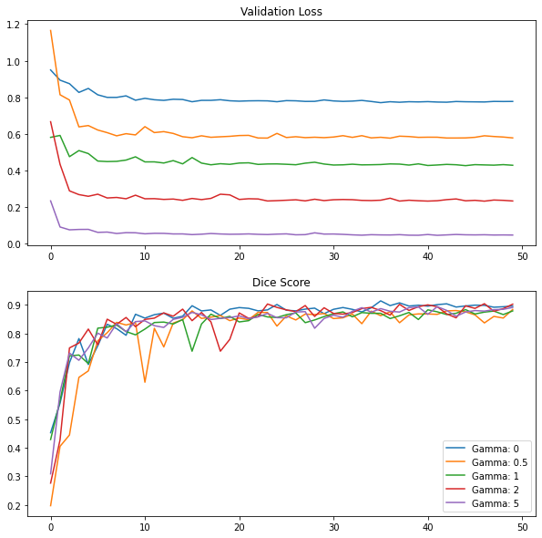

```python
gamma_test_values = [0, 0.5, 1, 2, 5]

fig, axs = plt.subplots(2, figsize=(10,10))

#initialise results arrays
loss_array = np.zeros((len(batch_test_values), len(learning_rate_test_values)))
dice_array = np.zeros((len(batch_test_values), len(learning_rate_test_values)))

for idx_gamma, gamma in enumerate(gamma_test_values):

    #create training and validating data loader
    training_data_loader = DataLoader(dataset=train_set, num_workers=num_workers, batch_size=5, shuffle=True)
    validating_data_loader = DataLoader(dataset=val_set, num_workers=num_workers, batch_size=80, shuffle=True)


    data_loader = {'train':training_data_loader,
                'validate':validating_data_loader}

    #initialise model and send it to GPU
    model = CNNSEG()
    model.cuda()

    loss_fn = FocalLoss(gamma=gamma)

    #initialise adam optimiser
    optimizer = torch.optim.Adam(model.parameters(), lr=0.0005)

    #train model
    train_loss, val_loss, dice_score = train(data_loader, optimizer, loss_fn, EPOCHS=50)


    axs[0].plot(val_loss, label='Gamma: '+str(gamma))
    axs[1].plot(dice_score, label='Gamma: '+str(gamma))

axs[0].set_title("Validation Loss")
axs[1].set_title("Dice Score")
plt.legend()
plt.show()
```

We see that the value of gamma that gives rise to the highest dice score is 0. Note that setting gamma to 0 reduces focal loss to cross entropy. So these results confirm the SegNet paper claiming that cross entropy is the best loss function.

We now train a model using batch size of 5, learning rate of 0.0005, and loss function of cross entropy. Setting this to train for 100 epochs and chosing the weights that result in highest dice score. This model will then be used throughout the rest of this paper.

```python
loss_fn = torch.nn.CrossEntropyLoss()
training_data_loader = DataLoader(dataset=train_set, num_workers=num_workers, batch_size=5, shuffle=True)
validating_data_loader = DataLoader(dataset=val_set, num_workers=num_workers, batch_size=80, shuffle=True)


data_loader = {'train':training_data_loader,
                'validate':validating_data_loader}

model = CNNSEG()
model.cuda()

optimizer = torch.optim.Adam(model.parameters(), lr=0.0005)

train_loss, val_loss, dice_score = train(data_loader, optimizer, loss_fn, EPOCHS=100, save_weights=True)
```

```python
weights = torch.load("/content/drive/MyDrive/NC2020/NC_cw2/segnet.pth")
model.load_state_dict(weights)
model.eval()
best_idx = np.argmax(dice_score)
print("Validation loss: ", val_loss[best_idx])
print("Dice score: ", np.max(dice_score))
```

```
Validation loss:  0.7720856666564941
Dice score:  0.9098284540438282
```

We run the validation set through the model and compare the output to the ground truth masks. We select 10 samples from the validation set, compute the predicted mask and also compute where the errors occurred in order to get an idea of how well the model performs and where it goes wrong.

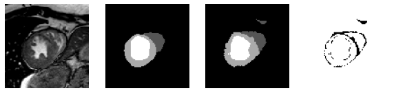

```
0.8781659519416434
```

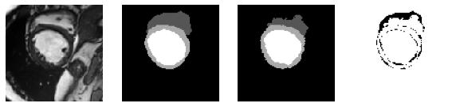

```
0.8761701570192643
```

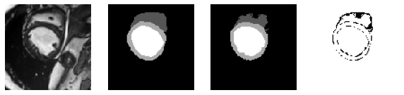

```
0.8914286785397353
```

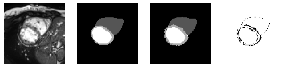

```
0.8920320203954757
```

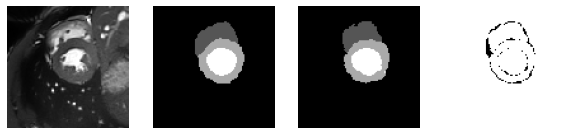

```
0.9359379180439382
```

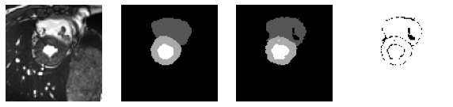

```
0.9377764267219465
```

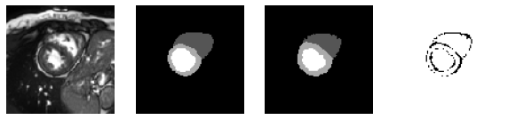

```
0.8899209435650265
```

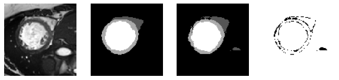

```
0.8887612116423853
```

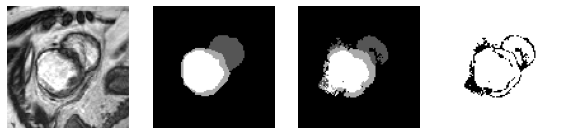

```
0.8228941049303562
```

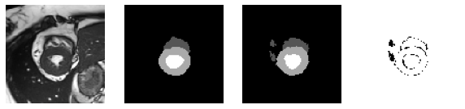

```
0.8991460095112913
```

```python
for idx in range(10):
    img, mask = val_set[idx]

    img_scale = img/255.

    img_scale = img_scale.view(1, 1, 96, 96)
    seg_soft = model(img_scale.cuda()).cpu()

    fig = plt.figure(figsize=(10,10))
    plt.subplot(1, 4, 1)
    plt.imshow(img, cmap='gray')
    plt.axis('off')
    plt.subplot(1,4,2)
    plt.imshow(mask, cmap='gray')
    plt.axis('off')
    plt.subplot(1,4,3)
    plt.imshow(torch.argmax(seg_soft, dim=1)[0], cmap='gray')
    plt.axis('off')
    plt.subplot(1, 4, 4)
    plt.imshow(mask == torch.argmax(seg_soft, dim=1)[0], cmap='gray')
    plt.axis('off')
    plt.show()
    print(np.mean([categorical_dice(mask, torch.argmax(seg_soft, dim=1)[0], label_class=c) for c in [0,1,2,3]]))
```

The first eight predicted masks fit the ground truth quite well with dice scores in the high 80s/low 90s. The penultimate one is an exception.

In the first eight examples, the model does a good job in segmenting with the errors being confined to thin strips along borders of the segments. The last image is of particular interest as the heart has a larger layer of pericardial fat surrounding it, the colour of which is nearly identical to that of the right ventricle. As a result, we see in the segmentation that the model classifies some of the pericardial layer as right ventricle.

The penultimate image is taken from a CMRI scan using a different pulse sequence which results in different structures appearing with different intensities. Since the majority of the data provided is from a different pulse sequence mechanism, the network will have a hard time learning that on sparse data. This issue could be solved by allowing more training examples from CMRI that employ that specific weighting. Another approach to solving this would be to apply some more preprocessing that would use a kernel of some kind to transform from one regime to another. Yet another solution could be to train two different models and train them on the different data. This network could use part of this model and apply transfer learning to each pulse sequence. There are approximately four different pulse sequences commonly used in cardiac imaging (T1, T2, DWI, FLAIR) (Preston, 2016). The dataset could be clustered and then depending on the cluster, be passed through the appropriate network.

After performing all the necessary hyper-parameter optimisation, we are now in a position to evaluate the model on the test data. We call the helper function provided that convert the files.

```python
import numpy as np
import os
import cv2

def rle_encoding(x):
    '''
    *** Credit to https://www.kaggle.com/rakhlin/fast-run-length-encoding-python ***
    x: numpy array of shape (height, width), 1 - mask, 0 - background
    Returns run length as list
    '''
    dots = np.where(x.T.flatten() == 1)[0]
    run_lengths = []
    prev = -2
    for b in dots:
        if (b > prev + 1): run_lengths.extend((b + 1, 0))
        run_lengths[-1] += 1
        prev = b
    return run_lengths


def submission_converter(mask_directory, path_to_save):
    writer = open(os.path.join(path_to_save, "submission.csv"), 'w')
    writer.write('id,encoding\n')

    files = os.listdir(mask_directory)

    for file in files:
        name = file[:-4]
        mask = cv2.imread(os.path.join(mask_directory, file), cv2.IMREAD_UNCHANGED)

        mask1 = (mask == 1)
        mask2 = (mask == 2)
        mask3 = (mask == 3)

        encoded_mask1 = rle_encoding(mask1)
        encoded_mask1 = ' '.join(str(e) for e in encoded_mask1)
        encoded_mask2 = rle_encoding(mask2)
        encoded_mask2 = ' '.join(str(e) for e in encoded_mask2)
        encoded_mask3 = rle_encoding(mask3)
        encoded_mask3 = ' '.join(str(e) for e in encoded_mask3)

        writer.write(name + '1,' + encoded_mask1 + "\n")
        writer.write(name + '2,' + encoded_mask2 + "\n")
        writer.write(name + '3,' + encoded_mask3 + "\n")

    writer.close()
```

We specify the path to the test data and set up the test data loader. Looping through the data loader, we predict the mask and store it in the relevant file. Finally we call the helper function and convert the masks into csv.

```python
data_path = '/content/drive/MyDrive/NC2020/NC_cw2/data/test'
num_workers = 8
batch_size = 1

test_set = TestDataset(data_path)
test_data_loader = DataLoader(dataset=test_set, num_workers=num_workers,batch_size=batch_size, shuffle=False)

for iteration, sample in enumerate(test_data_loader):
    img = sample
    img_scale = img/255.
    img_scale = img_scale.view(1, 1, 96, 96)
    seg_soft = model(img_scale.cuda()).cpu()

    base = test_set.img_files[iteration][:-16]
    number = test_set.img_files[iteration][-7:-4]
    cv2.imwrite(os.path.join(base,'mask','cmr'+number+'_mask.png'), np.array(torch.argmax(seg_soft[0], dim=0)))
```

```python
submission_converter('/content/drive/MyDrive/NC2020/NC_cw2/data/test/mask', '/content/drive/MyDrive/NC2020/NC_cw2/data/test/kaggle_submission')
```

Uploading this to Kaggle, we can see that this results in a final dice score of 0.84.

## Conclusion

We found that the overall model achieved a dice score of 0.84. Whilst this is a good start, there are more improvements that could be made. Firstly would be to look at the network architecture. Due to the relatively small amount of data available, a smaller encoder/decoder sequence could have resulted in more appropriate weights being found.

The most crucial factors that we experimented with were the learning rate and the batch size. We found that having either of these hyper-parameters at either extremes resulted in worse performing models. By performing a grid search in the hyper-parameter space, we attempted to find the 'Goldilocks' choice of batch size and learning rate.

We experimented briefly with different loss functions but concluded that the optimal one was the original cross entropy loss as mentioned in the SegNet paper.

By looking at the errors in the prediction, most errors occurred on the boundary of the segments. An issue which arose was the use of different CMRI pulse sequences which resulted in drastically different images.

One extension that was not made here is data augmentation. The data could be reflected, rotated, and possible add some small zero mean iid Gaussian noise. This would result in a much larger dataset for which we could train our model on.

CMRI is usually used to take videos (or sequence of slices) of hearts during a heartbeat. It would be very inefficient for a human to go through hundreds of slices and segmenting them by hand. The model we constructed could perform this much faster. A more optimised model could do this much faster and with a much higher accuracy and prone to less error than a human.

Ultimately, a dice score of 0.84 is a good indicator that SegNet works well at segmenting cardiac MR images.

# References

Badrinarayanan, V., Kendall, A. and Cipolla, R., 2015. Segnet: A Deep Convolutional Encoder-Decoder Architecture For Image Segmentation. [online] arXiv.org. Available at: https://arxiv.org/abs/1511.00561v3 [Accessed 14 December 2020].

O. Bernard, A. Lalande, C. Zotti, F. Cervenansky, et al. "Deep Learning Techniques for Automatic MRI Cardiac Multi-structures Segmentation and Diagnosis: Is the Problem Solved ?" in IEEE Transactions on Medical Imaging, vol. 37, no. 11, pp. 2514-2525, Nov. 2018 doi: 10.1109/TMI.2018.2837502

Chen, Chen et al. “Deep Learning for Cardiac Image Segmentation: A Review.” Frontiers in cardiovascular medicine vol. 7 25. 5 Mar. 2020, doi:10.3389/fcvm.2020.00025

Preston, David C. Magnetic Resonance Imaging (MRI) of the Brain and Spine: Basics, 7 Apr. 2016, case.edu/med/neurology/NR/MRI%20Basics.htm.